# Check 2: On-time vs. prolonged exiters

Conducting the analysis with stateELP

Guide home | Previous: Check 1: Cohort survival | Next: Check 3: Academic patterns

**Simulated data**

Every output on this page comes from the package’s simulated data. It shows what this step produces and how to read it. It says nothing about any real state: every gap, ratio and rate here comes from how the data were generated.

```r
library(stateELP)
```

## What this step answers

Check 2 asks **who exits on time, and who gets stuck?** It takes the entry cohort from Check 1 and splits it by exit outcome. It then compares the groups on who they are, on how they did on the state content assessment, and on the English language proficiency (ELP) levels they posted along the way.

A few terms. An English learner (EL) is a student classified as needing English language support. ELP is measured each year by the state’s ELP test. The simulated spec declares WIDA ACCESS, and its exit rule reads the Overall Composite. A student *exits* when they are reclassified as a former EL. A *cohort* is every student who entered EL status in the same grade in the same year.

The stage puts a human face on the “stuck” population. Check 1 asks whether exit timing is driven by English proficiency, as intended. Check 2 is its descriptive companion. Suppose prolonged classification goes with a characteristic such as disability status. Then a change to the exit threshold alone will not fix it. The change would move some students and leave the ones held back by something other than their English where they were.

## Sample

**Sample**

The K-2015 entry cohort — the same cohort Data Check 1 analyzes: 2,373 students who entered EL status in kindergarten in 2015, followed through 2025. They are split into on-time exiters (exited within 5 years [DERIVED — VERIFY]) and prolonged cases (exited later, or still classified when the window closes). Students who disappeared from the data are shown separately, in neither group.

In plain terms:

- **One entry cohort, the same one Check 1 analyzes.** Check 2 does not pick its own. `run_check2()` takes the row that Check 1’s `compute_cohorts()` marks as selected: the qualifying kindergarten cohort with the longest follow-up. In the simulated data that is K-2015, with 2,373 students followed through 2025.
- **Students already in EL status when the data begin are excluded.** Their entry was never observed, so their time in status cannot be measured.
- **Three groups, defined against the years observed.** *On time* means exiting within 5 years in status. The package dates an exit to the first year a student appears as former and counts that year as a year in status, with the entry year as year 1 (the same convention as Check 1). So a kindergarten entrant first seen as former in grade 4 exited in year 5, which is on time. *Prolonged* means everyone still in view who did not exit on time: late exiters plus students not observed to exit by the last year of data. *Disappeared* means last seen before the window closed, with no exit observed. Their outcome is unknown, so they belong to neither group.
- **Censored is not did-not-exit.** A student whose outcome the data do not show is *censored*. That covers the disappeared, and also students still classified when the data end: they might exit next year. This is why “prolonged” always means “prolonged within the years observed”.

This is not the state’s whole EL population, and it is not the cross-sectional sample Checks 3 and 4 use. A kindergarten cohort is also the best case for exit: students who enter in later grades are not in it.

## Status in the package

**Built.** Every result slot the stage’s instruction file names is filled: the exit flags, the crosstab with all five characteristic blocks, the academic summary, the trajectories, and the Type-gated blocked-groups check. The stage report (`inst/templates/check2_flows.qmd`) renders in Word and HTML.

What that means for you:

- You can run the stage end to end on your own data today.
- Several design choices are recorded as `[PROPOSED — CONFIRM]` in `internal_docs/NOTES-check2.md`. Examples: characteristics are read in the entry year; a zero count is shown as zero, not suppressed; “comparable point” means the same year in status. Read them before you report.
- **Not built:** repeating the analysis for later start grades as a view of its own, starting grade as a crosstab row block, a logistic regression that separates correlated characteristics, and a mobility row (the roster has no mobility field). The stage report names the first three as later additions.

## Before you start

Check 2 does not need Check 1’s results object. `run_check2()` calls Check 1’s `compute_cohorts()` itself and takes the cohort it selects. It does need that cohort to exist: if `compute_cohorts()` selects none, Check 2 has no sample. Running Check 1 first is still the sensible order, because Check 1’s report tells you how the cohort behaves.

| Input | Used for | If it is missing |
| --- | --- | --- |
| Roster: `STUDENT_ID`, `YEAR`, `GRADE`, `EL_STATUS` | The cohort, exit dating, the flags | Required. With no qualifying cohort every analysis slot is `NULL` and `res$meta$note` says why. |
| Roster: `LEFT_TRUNCATED` | Drops students already in status when the panel opens | Students entering in the panel’s first year are treated as left-truncated and dropped. |
| Roster: `HOME_LANGUAGE`, `GENDER`, `FRL` (low-income flag), `IEP` (special education), `SERVICE_MODEL` | The characteristic blocks, read in the entry year | That block (or row) is left out of the crosstab, not shown empty. |
| Roster: `DISTRICT_ID`, plus `policy$district_size_bands` in the spec | The district size block | Block left out. |
| Base table: annual-form scores on the ELP component your spec’s analyses run on (the simulated spec’s Overall Composite) | The initial ELP band block; the trajectories | Block left out; `$trajectories` is `NULL`. |
| Academic table | `$academic_summary` | `NULL`. |

From the spec, Check 2 reads `policy$timelines`, `policy$suppression$min_cell`, `policy$academic_benchmark$proficient_level`, `policy$district_size_bands`, `elp$bands`, `elp$level_scale`, and `policy$exit$types`. Within `policy$timelines`, the on-time allowance is `on_time_rule$default_years`. If that is absent, the package falls back to `essa_timeline_years`, then to `max_years_to_exit`. A `source` of `"provisional"` marks the timeline `[DERIVED — VERIFY]` in the Sample statement. If `elp$level_scale$type` is `"categorical"`, `$trajectories` is `NULL`, because category labels have no mean.

Two spec settings stop the run rather than degrade it:

- `policy$timelines$initial_elp_source` must be `"first_annual"` (or absent). The package derives the initial band only as the first annual score.
- An `on_time_rule` keyed by initial band (`by_initial_band`) needs a delivered `INITIAL_ELP` column on the roster. See Pitfalls.

## Run it

One call does the stage. Build the spec and the data bundle once, then pass both:

```r
spec   <- read_el_spec("00_SIM_EL_Spec")
bundle <- as_el_data(el_long_sim, roster = el_roster_sim,
                     academic = academic_long_sim, spec = spec)
res    <- run_check2(bundle, spec)
```

For your state, point `read_el_spec()` at your spec file and pass your own three tables to `as_el_data()` (see Setup). `run_check2()` takes two optional arguments:

- `start_grade`, default `"K"`. The stage’s guidance is written for a kindergarten cohort, and later start grades are not built as a view of their own. Other grades run, but read the Disappeared column with care. A student who finishes grade 12 still classified leaves the data and is counted as disappeared. In the simulated data, that is what fills a grade 3 cohort’s Disappeared column.
- `subject`, the academic subject for `$academic_summary`. It defaults to the spec’s first subject (ELA here); `run_check2(bundle, spec, subject = "Math")` reports the other.

The cohort comes from Check 1’s table. `SELECTED` marks the one both stages use:

```r
compute_cohorts(bundle, spec)
```

```
# A tibble: 5 × 6
  COHORT_LABEL COHORT_START_YEAR N_ENTRY FOLLOWUP_YEARS SELECTED SUPPRESSED
  <chr>                    <int>   <int>          <int> <lgl>    <lgl>
1 K-2015                    2015    2373             11 TRUE     FALSE
2 K-2016                    2016    2360             10 FALSE    FALSE
3 K-2017                    2017    2411              9 FALSE    FALSE
4 K-2018                    2018    2403              8 FALSE    FALSE
5 K-2019                    2019    2374              7 FALSE    FALSE
```

```r
res$meta$cohort
```

```
[1] "K-2015"
```

Under the hood, `run_check2()` chains the stage’s exported functions. You can call them yourself to inspect one piece:

```r
co       <- compute_cohorts(bundle, spec)
cohort   <- co$COHORT_LABEL[co$SELECTED]
flags    <- compute_exit_flags(bundle, spec, cohort)      # one row per student
profile  <- compute_cohort_profile(bundle, spec, flags)   # one row per student
crosstab <- compute_crosstab(flags, spec, profile = profile)
academic <- compute_academic_summary(bundle, spec, flags)
traj     <- compute_trajectories(bundle, spec, flags)
blocked  <- compute_blocked_groups(bundle, spec, flags)   # NULL unless Types 2-6
```

## What you get

```r
names(res)
```

```
[1] "flags"            "crosstab"         "profile"          "academic_summary"
[5] "trajectories"     "blocked_groups"   "meta"
```

### `$flags` and `$profile`: one row per student

These two slots hold student-level rows. **Do not print them, and do not share them.** Look at their size and columns, or at counts built from them:

```r
nrow(res$flags)
```

```
[1] 2373
```

```r
names(res$flags)
```

```
 [1] "STUDENT_ID"          "COHORT_LABEL"        "COHORT_START_YEAR"
 [4] "EXIT_YEAR_IN_STATUS" "LAST_YEAR_IN_STATUS" "ON_TIME_YEARS"
 [7] "EXIT_EVER"           "EXIT_MAX"            "EXIT_ONTIME"
[10] "NO_EXIT"             "DISAPPEARED"         "ON_TIME"
[13] "PROLONGED"           "EXIT_GROUP"
```

```r
colSums(res$flags[c("EXIT_EVER", "EXIT_MAX", "EXIT_ONTIME",
                    "NO_EXIT", "DISAPPEARED", "PROLONGED")])
```

```
  EXIT_EVER    EXIT_MAX EXIT_ONTIME     NO_EXIT DISAPPEARED   PROLONGED
       1941        1418         978         432           0        1395
```

```r
table(res$flags$EXIT_GROUP)
```

```
  on_time prolonged
      978      1395
```

```r
names(res$profile)
```

```
[1] "STUDENT_ID"         "HOME_LANGUAGE"      "GENDER"
[4] "FRL"                "IEP"                "SERVICE_MODEL"
[7] "DISTRICT_SIZE_BAND" "ELP_BAND"
```

The indicators come from shared helpers (`build_student_spans()` and `add_exit_flags()`), so Check 1 and Check 2 date exits the same way:

| Column | Meaning |
| --- | --- |
| `EXIT_EVER` | Exited at any point in the years observed. |
| `EXIT_MAX` | Exited within the maximum timeline (`policy$timelines$max_years_to_exit`, 6 years here). |
| `EXIT_ONTIME` | Exited within the student’s on-time timeline (`ON_TIME_YEARS`, from `on_time_rule`). |
| `NO_EXIT` | Still classified in the last year of data. |
| `DISAPPEARED` | Left the data before the window closed, with no exit observed. |
| `ON_TIME` / `PROLONGED` | The split: `PROLONGED` is late exiters plus `NO_EXIT`. |
| `EXIT_GROUP` | `on_time`, `prolonged` or `disappeared`: one value per student. |

The first three are nested: every on-time exiter is also a maximum-timeline exiter and an ever-exiter. What adds up is `EXIT_EVER` + `NO_EXIT` + `DISAPPEARED`, which equals the cohort.

`$profile` holds each student’s characteristics **in the entry year**. Two are derived, not delivered. `DISTRICT_SIZE_BAND` bands the entry-year district by its own current-EL count, using the spec’s bands. The package never uses a delivered district-size column. `ELP_BAND` is the first annual Overall Composite level on record, banded the same way Check 1 bands it. For most students that score is from the entry year; for a student untested that year it is the first later one.

### `$crosstab`: the cohort split by exit outcome

This is the stage’s main table. The display helper shows it as the stage report does:

```r
ft_check2_crosstab(res)
```

|  | All EL students | Exit_Ever Exited in the years observed | Exit_Max Exited within the maximum timeline | Exit_OnTime Exited within the on-time timeline | No_Exit Not observed exiting by the window's end | Disappeared Left the data before the window closed |
| --- | --- | --- | --- | --- | --- | --- |
| Total students | 2,373 | 1,941 | 1,418 | 978 | 432 | 0 |
| % of all EL students | 100% | 82% | 60% | 41% | 18% | 0% |
| Primary language |  |  |  |  |  |  |
| Spanish | 55% | 54% | 54% | 55% | 56% | — |
| Arabic | 8% | 8% | 8% | 8% | 9% | — |
| Portuguese | 8% | 8% | 7% | 7% | 7% | — |
| Mandarin | 5% | 5% | 5% | 6% | 5% | — |
| Haitian Creole | 5% | 5% | 5% | 5% | 5% | — |
| Gujarati | 5% | 5% | 5% | 5% | 6% | — |
| Other | 4% | 4% | 4% | 4% | 5% | — |
| Korean | 4% | 4% | 4% | 5% | — | — |
| Urdu | 4% | 4% | 4% | 3% | 4% | — |
| Tagalog | 3% | 3% | 3% | 3% | — | — |
| District size |  |  |  |  |  |  |
| 101-999 | 30% | 30% | 30% | 31% | 31% | — |
| 1,000+ | 70% | 70% | 70% | 69% | 69% | — |
| Other demographics |  |  |  |  |  |  |
| Male | 50% | 50% | 50% | 51% | 50% | — |
| Low SES | 74% | 73% | 74% | 73% | 75% | — |
| Special education | 15% | 11% | 11% | 10% | 36% | — |
| Type of EL services |  |  |  |  |  |  |
| ESL, pull-out | 30% | 31% | 31% | 32% | 27% | — |
| ESL, push-in | 22% | 21% | 21% | 22% | 25% | — |
| Transitional bilingual | 12% | 12% | 13% | 12% | 10% | — |
| Sheltered content instruction | 11% | 11% | 11% | 11% | 12% | — |
| Dual language / two-way bilingual | 10% | 10% | 9% | 9% | 10% | — |
| Newcomer program | 9% | 9% | 8% | 8% | 10% | — |
| Services refused | 6% | 6% | 6% | 6% | 7% | — |
| Initial ELP |  |  |  |  |  |  |
| 1.0-1.9 | 55% | 55% | 51% | 46% | 58% | — |
| 2.0-2.9 | 36% | 38% | 41% | 44% | 27% | — |
| 3.0-3.9 | 6% | 6% | 8% | 9% | 2% | — |
| 4.0-4.4 | — | — | — | — | 0% | — |
| 4.5-4.9 | — | — | — | — | 0% | — |
| (not reported) | 2% | 0% | 0% | 0% | 13% | — |

The six columns are All, then the five indicators. The report’s headers use the familiar spellings (Exit_Ever, Exit_Max, Exit_OnTime, No_Exit, Disappeared), and the slot uses the ALL-CAPS codes. The first two rows give the count in each column and its share of the cohort. Every block below them is **column percentages**: within one column, they show what that group is made of.

In the slot, the table is long, one row per block × row × column:

```r
names(res$crosstab)
```

```
[1] "BLOCK"      "BLOCK_TYPE" "FIELD"      "ROW"        "COLUMN"
[6] "N"          "N_BASE"     "PCT"        "SUPPRESSED"
```

```r
res$crosstab |>
  dplyr::filter(FIELD %in% "IEP") |>
  dplyr::select(ROW, COLUMN, N, N_BASE, PCT)
```

```
# A tibble: 6 × 5
  ROW               COLUMN          N N_BASE    PCT
  <chr>             <chr>       <int>  <int>  <dbl>
1 Special education ALL           358   2373  0.151
2 Special education EXIT_EVER     204   1941  0.105
3 Special education EXIT_MAX      150   1418  0.106
4 Special education EXIT_ONTIME   102    978  0.104
5 Special education NO_EXIT       154    432  0.356
6 Special education DISAPPEARED     0      0 NA
```

- `BLOCK_TYPE` says how a block’s rows relate. `"distribution"` rows split the column, so they sum to 100%. A `(not reported)` row keeps that true. `"indicator"` rows (Male, Low SES, Special education) are separate shares that sum to nothing. A student can count in all three or none.
- `N_BASE` is the denominator behind each `PCT`. For a distribution block it is the column total. For an indicator row it is the students in that column whose value was reported: an unreported value leaves the denominator rather than counting as “no”.
- `FIELD` names the roster column a row came from. `ROW` keeps your delivery’s own codes (for example `spa`). Readable labels are added only at display time, from `inst/lookups/Display_Labels.R`.
- `SUPPRESSED` marks cells under the spec’s `min_cell` (10 here). A suppressed cell has `N` and `PCT` set to `NA` and the row is kept. The display shows a dash. A **zero** is shown as zero, because an empty cell is not a small cell.
- A dash also appears down a column that no student landed in, because there is nobody to describe. That dash is not suppression. The column’s count in the first row says it is empty, and `SUPPRESSED` is `FALSE` there.
- In the Initial ELP block, `(not reported)` holds students with no annual Overall Composite score on record. In the simulated data these are students who took only the alternate form, and students whose composite was never reported because a domain was waived. Exit_Ever counts 0 of these 55 students, so the row piles up under No_Exit. The generator lets only annual-form students with a composite score exit (`sim_contract.md` §3.3). That is a modeling limit, not a finding. In your data, check how your exit rule treats these students before you read the row.

```r
res$crosstab |>
  dplyr::filter(SUPPRESSED) |>
  dplyr::select(BLOCK, ROW, COLUMN, N, PCT)
```

```
# A tibble: 10 × 5
   BLOCK            ROW     COLUMN          N   PCT
   <chr>            <chr>   <chr>       <int> <dbl>
 1 Primary language kor     NO_EXIT        NA    NA
 2 Primary language tgl     NO_EXIT        NA    NA
 3 Initial ELP      4.0-4.4 ALL            NA    NA
 4 Initial ELP      4.5-4.9 ALL            NA    NA
 5 Initial ELP      4.0-4.4 EXIT_EVER      NA    NA
 6 Initial ELP      4.5-4.9 EXIT_EVER      NA    NA
 7 Initial ELP      4.0-4.4 EXIT_MAX       NA    NA
 8 Initial ELP      4.5-4.9 EXIT_MAX       NA    NA
 9 Initial ELP      4.0-4.4 EXIT_ONTIME    NA    NA
10 Initial ELP      4.5-4.9 EXIT_ONTIME    NA    NA
```

In this run 10 cells are suppressed: small home-language groups in the `NO_EXIT` column, and the top initial bands, which are near-empty in a kindergarten cohort. The Disappeared column is empty (count 0, dashes below) because the simulated data have no student mobility (`sim_contract.md` §3.2). Expect a real Disappeared column in your own data.

### `$academic_summary`: achievement at the same year in status

How did on-time and prolonged students do on the content assessment at the same point in their own trajectories? The comparison point is the same **year in status** (year 1 is the entry year), not the same calendar year.

> Subject: ELA. Proficiency is level 4 or above on the state’s own scale. Rows run from year in status 4 to 11: the content assessment does not reach this cohort’s earlier grades, so those years have no rows at all, and year 6 is absent because no assessment was administered that year. A group with no students left to measure shows a count of zero, not a suppressed cell.

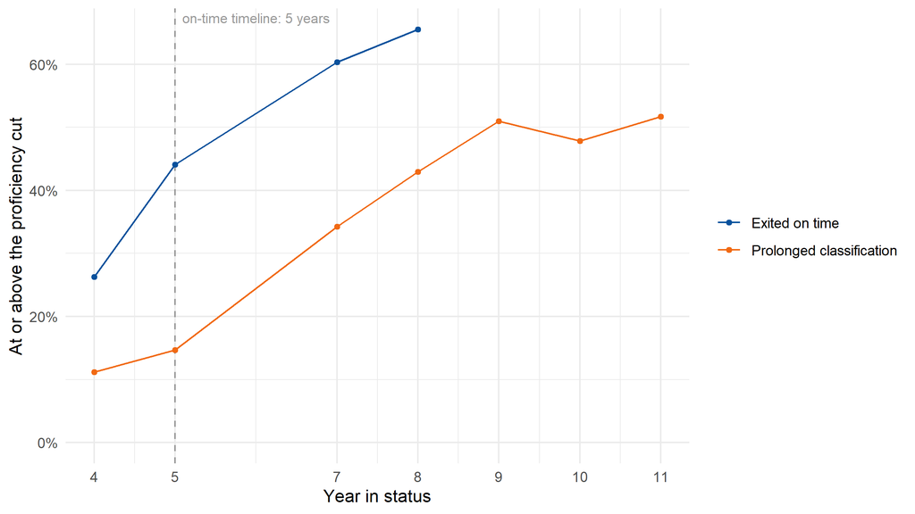

Share at or above the proficiency cut, by exit group and year in status (simulated data). A group with nobody left to test has no point.

```r
plot_academic_summary(res$academic_summary, spec)
```

```r
ft_check2_academic(res)
```

| Year in status | Exit group | Students scored | At or above the proficiency cut | Median scale score |
| --- | --- | --- | --- | --- |
| Y4 (grade 3) | Exited on time | 939 | 26% | 727 |
|  | Prolonged classification | 1,341 | 11% | 705 |
| Y5 (grade 4) | Exited on time | 943 | 44% | 744 |
|  | Prolonged classification | 1,338 | 15% | 712 |
| Y7 (grade 6) | Exited on time | 713 | 60% | 757 |
|  | Prolonged classification | 987 | 34% | 734 |
| Y8 (grade 7) | Exited on time | 537 | 66% | 761 |
|  | Prolonged classification | 1,294 | 43% | 743 |
| Y9 (grade 8) | Exited on time | 0 | — | — |
|  | Prolonged classification | 1,326 | 51% | 750 |
| Y10 (grade 9) | Exited on time | 0 | — | — |
|  | Prolonged classification | 911 | 48% | 748 |
| Y11 (grade 10) | Exited on time | 0 | — | — |
|  | Prolonged classification | 681 | 52% | 751 |

The slot’s columns are `EXIT_GROUP`, `YEAR_IN_STATUS`, `GRADE_MODAL` (the most common grade among those students), `N`, `N_SCORED`, `PCT_PROFICIENT`, `MEDIAN_SCALE` and `SUPPRESSED`. Proficient means `ACHIEVEMENT_LEVEL` at or above `policy$academic_benchmark$proficient_level`. The rate is the main measure because it means the same thing in every grade; a scale score does not. Students without a level that year are counted in `N` but not in `N_SCORED` or the rate.

The on-time group’s counts fall to zero in the later years. In the simulated data, former ELs leave the panel after their fourth monitoring year (`sim_contract.md` §3.3), so there is no one left to test. The same section notes that a real delivery keeps former ELs, so expect the on-time group to stay in view in your data. The table shows a zero there, not a suppressed cell.

### `$trajectories`: ELP levels, split by exit group

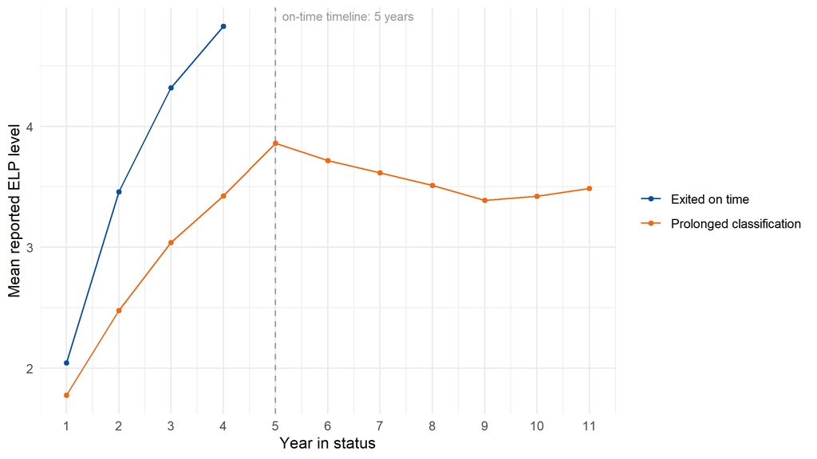

Mean reported ELP level by year in status, one line per exit group (simulated data). There is no pooled cohort line, by design.

```r
plot_trajectories(res$trajectories$levels, spec)
```

`$trajectories$levels` holds `EXIT_GROUP`, `YEAR_IN_STATUS`, `N`, `MEAN_LEVEL`, `MEDIAN_LEVEL` and `SUPPRESSED`. Use `plot_trajectories(..., measure = "median")` for medians. The on-time line stops when its students exit, because former ELs take no ELP test.

`$trajectories$composition` shows who is still being tested each year. Its `PCT_OF_MEASURED` column is each group’s share of the students with a score:

```r
ft_check2_composition(res)
```

| Exit group | Y1 | Y2 | Y3 | Y4 | Y5 | Y6 | Y7 | Y8 | Y9 | Y10 | Y11 |
| --- | --- | --- | --- | --- | --- | --- | --- | --- | --- | --- | --- |
| Exited on time | 42% | 42% | 42% | 31% | 0% | 0% | 0% | 0% | 0% | 0% | 0% |
| Prolonged classification | 58% | 58% | 58% | 69% | 100% | 100% | 100% | 100% | 100% | 100% | 100% |

Here the on-time group is 42% of the students tested in year 1 and none of them by year 5. That is why the package never draws one cohort-average line. The plotting function refuses a frame without the group column:

```r
no_groups <- res$trajectories$levels[c("YEAR_IN_STATUS", "MEAN_LEVEL")]
tryCatch(plot_trajectories(no_groups), error = conditionMessage)
```

```
[1] "plot_trajectories() needs a data frame with EXIT_GROUP, YEAR_IN_STATUS, MEAN_LEVEL; pass the matching slot of run_check2()."
```

### `$meta`

`$meta` carries what the report’s captions need. The Sample statement, the cohort, its size and the on-time text are all here:

```r
str(res$meta[c("cohort", "cohort_n", "on_time_text", "on_time_provisional",
               "academic_subject", "type_gate_applies")])
```

```
List of 6
 $ cohort             : chr "K-2015"
 $ cohort_n           : int 2373
 $ on_time_text       : chr "5 years"
 $ on_time_provisional: logi TRUE
 $ academic_subject   : chr "ELA"
 $ type_gate_applies  : logi FALSE
```

`on_time_provisional` is `TRUE` when `policy$timelines$source` is `"provisional"`. The Sample statement then flags the timeline `[DERIVED — VERIFY]`. `band_clock_note` is `NA` unless the on-time rule varies by initial band (see Pitfalls). `blocked_note` explains an empty Additional check.

## How to read it

**Start with the first two rows.** They give the balance of the cohort. Here 978 of 2,373 students exited on time (41%), and 1,395 are prolonged: 963 late exiters plus 432 not observed to exit by 2025. Check the identity: `EXIT_EVER` + `NO_EXIT` + `DISAPPEARED` = All. These numbers illustrate the machinery, nothing more.

**Then read each block down and across.** Read down a column to see what a group is made of. Read across a row to see how groups differ. The crosstab has no Prolonged column. For the sharpest contrast, compare `EXIT_ONTIME` with `NO_EXIT`. A characteristic over-represented among prolonged students is a candidate explanation for why they are still classified. One spread evenly across the groups is not. For example, special education students are 10% of on-time exiters and 36% of the students not observed to exit in this simulated cohort. In real data, a gap like that would raise a question for the recommendation: a threshold change would not reach those students. Here, the generator built it in.

**Ask whether the on-time group is already academically stronger.** In year 4 (mostly grade 3), 26% of on-time exiters and 11% of prolonged students are proficient in ELA in the simulated data. Some gap is built into the definitions: on-time exiters cleared an English bar, and the content test is in English. The useful question is whether the gap is larger than that explains, and whether it persists at similar ELP levels. The trajectory figure lets you check the ELP side.

**Read each trajectory line on its own.** A line shows how the students in that group scored while they were still classified. A pooled average falls for two reasons it cannot separate: students growing less, and the fastest growers leaving. The composition table shows the second. The same effect works inside the prolonged line: its late exiters stop testing once they exit, so its later years increasingly describe students who never exited.

**This is not automatically about the cut score.** Findings here concern how policies, programs, population and exit criteria interact. The right response may be a program or support change, not a threshold change.

## Pitfalls

- **Never fold Disappeared students into either group.** Censored is not did-not-exit. They have their own column and their own `EXIT_GROUP` value. The simulated cohort has none; yours probably will.
- **Do not average time to exit.** `$flags` carries `EXIT_YEAR_IN_STATUS`, and its mean is tempting. Censoring biases it: the students still classified have no exit year to average. Use Check 1’s median years to exit and its share exited within the timeline instead.
- **The window is finite.** `NO_EXIT` means “not observed exiting by 2025”, not “will never exit”. `EXIT_MAX` and `EXIT_ONTIME` count against the years available. Say so in every caption you write.
- **Nested columns do not add.** Only Ever + No_Exit + Disappeared sums to All.
- **Mind the denominators.** Distribution blocks use the column total; indicator rows use students with a reported value. `N_BASE` tells you which.
- **Suppressed cells stay `NA`.** Do not back them out by subtraction. Never lower `min_cell` or pool cohorts or grades to make cells appear. If you derive a new share (for example a Prolonged column from `N`), run `apply_suppression()` on it before you report it.
- **Description, not cause.** A crosstab shows one characteristic at a time. Two that travel together, such as district size and program model, cannot be told apart here. The model that would separate them is not built.
- **Never plot a cohort-average ELP line over time without splitting by exit group.** The fastest growers leave, so the average of whoever remains drifts down even if no student slows.
- **One kindergarten cohort is the best case.** Do not read it as the state’s overall exit picture. Later entrants, including newcomers in upper grades, are not in it.
- **An on-time rule keyed by initial band changes the Initial ELP block.** If `on_time_rule$by_initial_band` is set, each band has its own deadline, and `EXIT_ONTIME` down that block restates the policy rather than describing students. `res$meta$band_clock_note` then carries the deadlines, and the report shows it as a warning. Read `EXIT_MAX`, which uses one window for everyone, down that block instead. Such a rule also reads the roster’s delivered `INITIAL_ELP`, while the crosstab bands the first annual score. The two can disagree for a student, which the build notes record as an open issue.
- **Watch for circularity under a Type 3 rule.** If the exit rule itself includes an academic criterion, the groups are partly defined by the score the academic summary compares. The package does not flag this on its own yet.
- **Simulated gaps are parameters.** Every group difference in the simulated data was set by the generator. None is a finding.
- **The results object is not shareable.** `$flags` and `$profile` are one row per student. Keep a saved `res` out of any folder you send to others.

## Decide before moving on

- **Do specific subgroups need separate treatment in Checks 3 and 4?** A group heavily over-represented among prolonged students may need its own analysis there, rather than being averaged into the whole.
- **What equity considerations must the final recommendation address explicitly?** In particular, note any characteristic that separates the prolonged group but that a threshold change would leave untouched.

Record both answers. Checks 3 and 4 and the final recommendation draw on them.

## Additional checks for multi-criterion exit rules

Some states exit students on more than one criterion: a composite plus a domain floor, or a profile across domains. The package names six exit-rule types (Types 2–6 have more than one criterion). For these, Check 2 adds the students **blocked by exactly one criterion** as extra comparison rows. If such a group looks systematically different from the cohort, that criterion is screening on something other than what the main score screens on.

The spec declares the type. Check it like this:

```r
spec_exit_types(spec)
```

```
[1] 1
```

```r
el_exit_typology()[as.character(spec_exit_types(spec))]
```

```
                               1
"Single overall composite score"
```

```r
spec_has_type(spec, 2:6)
```

```
[1] FALSE
```

```r
is.null(res$blocked_groups)
```

```
[1] TRUE
```

The simulated spec is Type 1, a single overall composite, so `$blocked_groups` is `NULL`. `res$meta$blocked_note` says why:

> The exit rule is declared as Type 1 (a single overall composite), so there are no blocked-by-one-criterion groups to compare and this check does not apply. Declare the additional criteria in `spec$policy$exit$pathways` and set `types` to activate it.

For a Type 2–6 spec, the slot holds `BLOCKED_BY`, `COLUMN`, `N`, `N_BASE`, `PCT` and `SUPPRESSED`. `PCT` is the group’s share of each exit column. The groups come from Prep 2’s `compute_criteria_crosswalk()`, so the two stages agree on who is blocked by what. A student blocked by different criteria in different years is counted under the one that blocked them most often. Show the table with:

```r
ft_check2_blocked_groups(res)
```

A multi-criterion spec can still come back `NULL` if no cohort student is blocked by exactly one criterion. `res$meta$type_gate_applies` tells the two cases apart, and `blocked_note` words each one.

## Render the stage report

The stage report carries the authored walkthrough, every table and figure above, and the Decide box. Render it with:

```r
render_step("check2")                    # reports/check2_flows.docx and .html
render_step("check2", formats = "html")  # HTML only
```

`render_step()` scans the output for student IDs and stops if it finds any. The example report on the simulated data is on the project site.

The report builds its own results from the simulated data. For your state, compute the results yourself, then render from the saved file. Pass full paths: the report renders in a temporary folder.

```r
res <- run_check2(bundle, spec)                    # your bundle and spec
dir.create("results", showWarnings = FALSE)        # not a shared folder
saveRDS(res, "results/check2_results.rds")
files <- render_step(
  "check2",
  spec_file    = normalizePath("specs/XX_EL_Spec.R", winslash = "/"),
  results_file = "results/check2_results.rds",
  check_disclosure = FALSE
)
check_output_disclosure(files, bundle)             # scan against your IDs
```

Turn the automatic scan off with `check_disclosure = FALSE`: it can only build the simulated bundle, so it would check your report against the wrong IDs. `check_output_disclosure()` then checks the files against every `STUDENT_ID` in your bundle, and stops if any appears.

Run `render_step()` from a project folder that has no `R/` subfolder. The report treats a working folder with an `R/` subfolder as the package’s source and tries to load it with `devtools::load_all()`.

Guide home | Previous: Check 1: Cohort survival | Next: Check 3: Academic patterns